# rSpacing user manual: workflow with real APSIMx results

Maurizio Bagnara

# 1 About this manual

This vignette is the main entry point for a new `rSpacing` user. It explains the complete workflow from request construction to model execution, result inspection, plotting, soil and management diagnostics, and preparation of advanced analyses. The emphasis is not only on function syntax, but also on **what each returned object means**, **which checks should be performed**, and **which conclusions are supported by the available APSIMx output**.

The package has two distinct operating modes:

1. **Result-reading and analysis mode.** A previously imported `spacing_result` is inspected without requiring .NET, APSIMx, or the C# source tree. This is the mode used while the vignette is built.
2. **Model-execution mode.** `rSpacing` constructs a request, calls the external `Spacing.Tool2` runtime, captures logs and provenance, and imports the generated APSIMx outputs. This mode requires a compatible C# solution and .NET runtime.

A new user should first work through the vignette with the supplied fixture, then configure the external runtime and execute a small mock-weather run, and only afterwards start long rotations, Morris analyses, or uncertainty ensembles.

# 2 Reproducible example used by the manual

This vignette uses a single real model run that has already been imported as a `spacing_result`:

```
inst/extdata/reference_maize/result.rds
```

The run was produced with `Spacing.Tool2` v0.09.05 and `mock = TRUE` weather data. APSIMx is not rerun while the vignette is built. All subsequent tables and plots are derived from the real fixture.

The fixture represents a Maize example and is designed for documentation and regression checking. `mock = TRUE` means that the meteorological input is generated by the workflow rather than retrieved from an external service. The fixture demonstrates package behaviour, but it is not a site-calibrated agronomic experiment.

**How to read the next table.** The installed `rSpacing` version should match the package being tested, the fixture path should resolve to `inst/extdata/reference_maize/result.rds` in the source tree or to the installed `extdata` directory, and the object must inherit from `spacing_result`. If any of these checks fails, stop before interpreting tables or plots.

### 2.0.1 What this check does

The chunk records the package version, the exact fixture used, and the object class. This is the minimum provenance needed to understand which data support the remainder of the manual. A `spacing_result` is not a single data frame: it is a structured object containing imported CSV tables, APSIMx DataStore tables, run metadata, request information, units, files, and diagnostic evidence.

```r
data.frame(
  rSpacing = as.character(utils::packageVersion("rSpacing")),
  fixture = normalizePath(fixture_path, winslash = "/"),
  object_class = paste(class(result), collapse = "/")
)
```

```
#>   rSpacing
#> 1   0.10.5
#>                                                                                                                fixture
#> 1 C:/Users/maurizio.bagnara/Desktop/Internship Yuzhuo/Workspace APSIM/rSpacing/inst/extdata/reference_maize/result.rds
#>     object_class
#> 1 spacing_result
```

# 3 End-user functions

### 3.0.1 Choosing the correct function family

The table groups the public API by task. In normal use, start with configuration and request functions, obtain a `spacing_result`, and then use dedicated accessors rather than navigating internal lists. Soil and management helpers build validated inputs; plotting functions visualise imported evidence; run-spec constructors support reproducible multi-year scenarios; advanced functions support batch collection and parameter validation.

Functions not exported by the package are implementation details. Calling them with `rSpacing:::` makes analyses fragile because internal interfaces may change without notice.

```r
api <- data.frame(
  area = c(
    "Configuration", "Weather", "Request and run", "Results", "Soil",
    "Management", "Plots", "Run spec", "Advanced analyses"
  ),
  functions = c(
    "spacing_config(); validate_spacing_config()",
    "read_spacing_met(); write_spacing_met(); validate_spacing_met(); plot_spacing_met()",
    "new_spacing_request(); validate_spacing_request(); run_spacing(); read_spacing()",
    "spacing_daily(); spacing_report(); spacing_crop_summary(); spacing_units()",
    "new_spacing_soil_spec(); spacing_soil_layers(); plot_spacing_soil_profile()",
    "spacing_irrigation(); spacing_fertilisation(); spacing_apply_irrigation(); spacing_apply_fertilisation()",
    "plot_spacing_daily(); plot_spacing_report(); plot_spacing_soil_profile()",
    "new_spacing_rotation_spec(); new_spacing_management_spec(); new_spacing_run_spec()",
    "collect_spacing(); spacing_parameter_catalogue(); validate_spacing_parameters()"
  ),
  stringsAsFactors = FALSE
)
knitr::kable(api)
```

| area | functions |
| --- | --- |
| Configuration | spacing_config(); validate_spacing_config() |
| Weather | read_spacing_met(); write_spacing_met(); validate_spacing_met(); plot_spacing_met() |
| Request and run | new_spacing_request(); validate_spacing_request(); run_spacing(); read_spacing() |
| Results | spacing_daily(); spacing_report(); spacing_crop_summary(); spacing_units() |
| Soil | new_spacing_soil_spec(); spacing_soil_layers(); plot_spacing_soil_profile() |
| Management | spacing_irrigation(); spacing_fertilisation(); spacing_apply_irrigation(); spacing_apply_fertilisation() |
| Plots | plot_spacing_daily(); plot_spacing_report(); plot_spacing_soil_profile() |
| Run spec | new_spacing_rotation_spec(); new_spacing_management_spec(); new_spacing_run_spec() |
| Advanced analyses | collect_spacing(); spacing_parameter_catalogue(); validate_spacing_parameters() |

Non-exported functions are implementation details and should not be called with `rSpacing:::`.

# 4 Request and execution

### 4.0.1 Building and validating a request

A request describes **what should be simulated**. The example specifies coordinates, crop, mock-weather mode, and a scenario identifier. `validate_spacing_request()` checks the R object before any external process starts, so malformed inputs can be corrected without creating partial APSIMx runs.

**How to read the printed request.** Confirm coordinates, rotation or crop, years when supplied, scenario identifier, output destinations, and the `mock` flag. Validation confirms structure and admissible values; it does not prove that the external runtime is installed or that APSIMx will complete.

```r
request <- new_spacing_request(
  latitude = 44.9,
  longitude = 10.63,
  rotation = "Maize",
  mock = TRUE,
  scenario_id = "reference_maize"
)
validate_spacing_request(request)
print(request)
```

```
#> <spacing_request>
#>   location: 44.900000, 10.630000
#>   rotation: Maize
#>   mock:     TRUE
```

The run is normally executed with the following code. It is not evaluated here because it requires the local C# solution.

### 4.0.2 Executing the external model

The code is intentionally shown but not evaluated during vignette construction. `spacing_config()` identifies the local `Spacing.Tool2` environment; `validate_spacing_config(..., check_dotnet = TRUE)` verifies required paths and the .NET command; `run_spacing()` executes the request and captures status, standard output, standard error, and generated files; `read_spacing()` imports the completed run into a `spacing_result`.

The example reads the root from `RSPACING_SPACING_ROOT` instead of embedding a personal path. For the current two-repository workflow, this variable should point to the sibling `apsim` directory containing `src/Spacing.Tool2`. Always inspect the run status and logs before analysing outputs. `error_on_status = TRUE` is appropriate for interactive testing because a non-zero external status stops immediately.

```r
spacing_root <- Sys.getenv("RSPACING_SPACING_ROOT")
if (!nzchar(spacing_root)) {
  stop(
    "Set RSPACING_SPACING_ROOT to the local directory containing ",
    "the Spacing.Tool2 solution before running the model."
  )
}

cfg <- spacing_config(spacing_root)
validate_spacing_config(cfg, check_dotnet = TRUE)
run <- run_spacing(cfg, request, error_on_status = TRUE, echo = TRUE)
result <- read_spacing(run)
```

# 5 Result inventory

### 5.0.1 Understanding the result object

Printing the object gives a concise overview; `inventory_spacing_result()` provides a systematic list of imported components. Use the inventory to answer three questions before analysis: Which tables exist? Which files were discovered? Which components are empty or unavailable?

The inventory reports availability, not scientific suitability. A table can exist but still lack the variable, temporal resolution, or unit needed for a particular conclusion.

```r
print(result)
```

```
#> <spacing_result>
#>   databases: 1
#>   csv files:  3
#>   apsimx:     1
```

```r
knitr::kable(inventory_spacing_result(result))
```

| source | table | class | rows | columns | has_date | has_year | has_doy | numeric_variables | empty |
| --- | --- | --- | --- | --- | --- | --- | --- | --- | --- |
| csv | crop_summary_CELL_449_106_CELL_449_106_S1_tool2_cli.csv | data.frame | 0 | 8 | FALSE | FALSE | FALSE |  | TRUE |
| csv | daily_CELL_449_106_CELL_449_106_S1_tool2_cli.csv | data.frame | 12418 | 71 | TRUE | TRUE | TRUE | CheckpointID, SimulationID, Year, DOY, Tx, Tn, Rain_mm, Radn_MJm2, Wind_ms, VP_hPa, ET0_mm, PotEvapSoil_mm, ActEvapSoil_mm, Runoff_mm, Perc_mm, LeachNO3_kgNha, Irrig_mm, SWmm(1), SWmm(2), SWmm(3), SWm… | FALSE |
| csv | report_CELL_449_106_CELL_449_106_S1_tool2_cli.csv | data.frame | 34 | 11 | TRUE | TRUE | FALSE | CheckpointID, SimulationID, Year, Maize_GrainYield_kgha, Maize_Biomass_kgha, Maize_LAI, SoilNO3_kgha | FALSE |
| datastore:spacing_CELL_449_106__CELL_449_106_S1__tool2_cli.db | DailyReport | data.frame | 12418 | 69 | TRUE | TRUE | TRUE | CheckpointID, SimulationID, Year, DOY, Tx, Tn, Rain_mm, Radn_MJm2, Wind_ms, VP_hPa, ET0_mm, PotEvapSoil_mm, ActEvapSoil_mm, Runoff_mm, Perc_mm, LeachNO3_kgNha, Irrig_mm, SWmm.1., SWmm.2., SWmm.3., SWm… | FALSE |
| datastore:spacing_CELL_449_106__CELL_449_106_S1__tool2_cli.db | Report | data.frame | 34 | 9 | TRUE | TRUE | FALSE | CheckpointID, SimulationID, Year, Maize_GrainYield_kgha, Maize_Biomass_kgha, Maize_LAI, SoilNO3_kgha | FALSE |
| datastore:spacing_CELL_449_106__CELL_449_106_S1__tool2_cli.db | _Checkpoints | data.frame | 1 | 4 | FALSE | FALSE | FALSE | ID, OnGraphs | FALSE |
| datastore:spacing_CELL_449_106__CELL_449_106_S1__tool2_cli.db | _InitialConditions | data.frame | 83 | 10 | FALSE | FALSE | FALSE | CheckpointID, SimulationID, Total | FALSE |
| datastore:spacing_CELL_449_106__CELL_449_106_S1__tool2_cli.db | _Messages | data.frame | 1928 | 6 | TRUE | FALSE | FALSE | CheckpointID, SimulationID, MessageType | FALSE |
| datastore:spacing_CELL_449_106__CELL_449_106_S1__tool2_cli.db | _Simulations | data.frame | 1 | 3 | FALSE | FALSE | FALSE | ID | FALSE |
| datastore:spacing_CELL_449_106__CELL_449_106_S1__tool2_cli.db | _Units | data.frame | 11 | 3 | FALSE | FALSE | FALSE |  | FALSE |

### 5.0.2 Accessing daily, report, crop-summary, and unit tables

Dedicated accessors provide stable interfaces to common outputs. The daily table is required here, so strict extraction is used. Report and crop-summary tables are optional because their availability depends on the APSIMx reporting configuration. `spacing_units()` provides the evidence needed to interpret column scales.

Only the first 20 rows are displayed. The preview is for orientation, not for calculating totals or final values. For cumulative fluxes use the complete daily table; for end-of-cycle summaries prefer the appropriate report or crop-specific column and verify units before comparison.

```r
daily <- spacing_daily(result, strict = TRUE, allow_empty = FALSE)
report <- spacing_report(result, strict = FALSE, allow_empty = TRUE)
crop_summary <- spacing_crop_summary(result, strict = FALSE, allow_empty = TRUE)
units <- spacing_units(result)

knitr::kable(preview(daily), caption = "Daily: first 20 rows")
```

Daily: first 20 rows

| CheckpointName | CheckpointID | SimulationName | SimulationID | Zone | Clock.Today | Year | DOY | Tx | Tn | Rain_mm | Radn_MJm2 | Wind_ms | VP_hPa | ET0_mm | PotEvapSoil_mm | ActEvapSoil_mm | Runoff_mm | Perc_mm | LeachNO3_kgNha | Irrig_mm | SWmm(1) | SWmm(2) | SWmm(3) | SWmm(4) | SWmm(5) | SWmm(6) | SoilSWtot_mm | NO3_kgha(1) | NO3_kgha(2) | … |
| --- | --- | --- | --- | --- | --- | --- | --- | --- | --- | --- | --- | --- | --- | --- | --- | --- | --- | --- | --- | --- | --- | --- | --- | --- | --- | --- | --- | --- | --- | --- |
| Current | 1 | CELL_449_106__CELL_449_106_S1__tool2_cli | 1 | Field | 1/1/1990 12:00:00 AM | 1990 | 1 | 8.6 | -5.1 | 0.0 | 3.44 | 1.5 | 4.19 | 0 | 0.5231468 | 0.4686527 | 0.0000000 | 0.0000000 | 0.0000000 | 0 | 47.53135 | 45.00000 | 87.00000 | 84.00000 | 81.00000 | 156.0000 | 500.5313 | 9.379577 | 9.757363 | … |
| Current | 1 | CELL_449_106__CELL_449_106_S1__tool2_cli | 1 | Field | 1/2/1990 12:00:00 AM | 1990 | 2 | 7.8 | -6.2 | 15.7 | 4.24 | 1.7 | 3.85 | 0 | 0.6263397 | 0.5611216 | 0.5309513 | 0.0107166 | 0.0030609 | 0 | 57.72916 | 48.08708 | 87.92612 | 84.27784 | 81.08335 | 156.0250 | 515.1286 | 8.697033 | 10.137547 | … |
| Current | 1 | CELL_449_106__CELL_449_106_S1__tool2_cli | 1 | Field | 1/3/1990 12:00:00 AM | 1990 | 3 | 7.8 | -5.7 | 0.0 | 3.90 | 1.8 | 3.99 | 0 | 0.5798075 | 0.5194395 | 0.0000000 | 0.0446006 | 0.0127818 | 0 | 54.29097 | 49.20408 | 88.90951 | 84.76734 | 81.28855 | 156.1041 | 514.5645 | 8.244307 | 10.199635 | … |
| Current | 1 | CELL_449_106__CELL_449_106_S1__tool2_cli | 1 | Field | 1/4/1990 12:00:00 AM | 1990 | 4 | 8.4 | -4.7 | 0.0 | 4.92 | 2.2 | 4.30 | 0 | 0.7491533 | 0.6711643 | 0.0000000 | 0.1081770 | 0.0310997 | 0 | 51.73251 | 49.26396 | 89.61585 | 85.32189 | 81.59855 | 156.2524 | 513.7852 | 7.951525 | 10.106728 | … |
| Current | 1 | CELL_449_106__CELL_449_106_S1__tool2_cli | 1 | Field | 1/5/1990 12:00:00 AM | 1990 | 5 | 7.7 | -4.8 | 0.0 | 4.75 | 2.6 | 4.28 | 0 | 0.7129227 | 0.4825515 | 0.0000000 | 0.1995553 | 0.0575393 | 0 | 50.13021 | 48.76860 | 89.96167 | 85.81383 | 81.96313 | 156.4656 | 513.1031 | 7.777241 | 9.946027 | … |
| Current | 1 | CELL_449_106__CELL_449_106_S1__tool2_cli | 1 | Field | 1/6/1990 12:00:00 AM | 1990 | 6 | 7.5 | -6.0 | 0.0 | 3.68 | 3.1 | 3.91 | 0 | 0.5418733 | 0.4854999 | 0.0000000 | 0.3100442 | 0.0896426 | 0 | 49.00565 | 48.08536 | 89.99878 | 86.16931 | 82.32499 | 156.7234 | 512.3075 | 7.678320 | 9.774544 | … |
| Current | 1 | CELL_449_106__CELL_449_106_S1__tool2_cli | 1 | Field | 1/7/1990 12:00:00 AM | 1990 | 7 | 8.6 | -4.9 | 0.0 | 3.51 | 2.7 | 4.26 | 0 | 0.5351217 | 0.4794543 | 0.0000000 | 0.4273719 | 0.1238801 | 0 | 48.22450 | 47.37094 | 89.81043 | 86.36165 | 82.63599 | 156.9972 | 511.4007 | 7.633315 | 9.615300 | … |
| Current | 1 | CELL_449_106__CELL_449_106_S1__tool2_cli | 1 | Field | 1/8/1990 12:00:00 AM | 1990 | 8 | 9.2 | -4.4 | 0.0 | 4.55 | 3.2 | 4.40 | 0 | 0.7057402 | 0.6323516 | 0.0000000 | 0.5388529 | 0.1565651 | 0 | 47.52480 | 46.70680 | 89.47934 | 86.39695 | 82.86428 | 157.2573 | 510.2295 | 7.626240 | 9.478931 | … |
| Current | 1 | CELL_449_106__CELL_449_106_S1__tool2_cli | 1 | Field | 1/9/1990 12:00:00 AM | 1990 | 9 | 8.4 | -4.7 | 16.1 | 3.58 | 2.9 | 4.32 | 0 | 0.5451156 | 0.4884648 | 0.6956170 | 0.6448132 | 0.1877648 | 0 | 57.96196 | 49.32989 | 90.03451 | 86.58822 | 83.08146 | 157.5046 | 524.5006 | 7.065195 | 9.653865 | … |
| Current | 1 | CELL_449_106__CELL_449_106_S1__tool2_cli | 1 | Field | 1/10/1990 12:00:00 AM | 1990 | 10 | 7.9 | -4.8 | 0.0 | 5.13 | 2.9 | 4.28 | 0 | 0.7728711 | 0.6925864 | 0.0000000 | 0.7509459 | 0.2191144 | 0 | 54.28079 | 50.12293 | 90.66103 | 86.91006 | 83.33004 | 157.7522 | 523.0571 | 6.691148 | 9.591439 | … |
| Current | 1 | CELL_449_106__CELL_449_106_S1__tool2_cli | 1 | Field | 1/11/1990 12:00:00 AM | 1990 | 11 | 8.1 | -4.3 | 0.0 | 4.85 | 1.2 | 4.44 | 0 | 0.7380353 | 0.6613921 | 0.0000000 | 0.8606193 | 0.2515829 | 0 | 51.73516 | 49.90502 | 91.03423 | 87.24731 | 83.60522 | 158.0081 | 521.5351 | 6.454458 | 9.420841 | … |
| Current | 1 | CELL_449_106__CELL_449_106_S1__tool2_cli | 1 | Field | 1/12/1990 12:00:00 AM | 1990 | 12 | 8.7 | -5.6 | 2.2 | 4.96 | 2.1 | 4.04 | 0 | 0.7510169 | 0.6730593 | 0.0000000 | 0.9735042 | 0.2850635 | 0 | 51.48155 | 49.67990 | 91.22793 | 87.54150 | 83.88611 | 158.2715 | 522.0885 | 6.237636 | 9.254854 | … |
| Current | 1 | CELL_449_106__CELL_449_106_S1__tool2_cli | 1 | Field | 1/13/1990 12:00:00 AM | 1990 | 13 | 8.5 | -4.2 | 10.4 | 5.20 | 1.0 | 4.47 | 0 | 0.7981893 | 0.7153607 | 0.0054922 | 1.0925570 | 0.3204099 | 0 | 56.99788 | 51.18990 | 91.81652 | 87.92401 | 84.19748 | 158.5493 | 530.6751 | 5.804843 | 9.189291 | … |
| Current | 1 | CELL_449_106__CELL_449_106_S1__tool2_cli | 1 | Field | 1/14/1990 12:00:00 AM | 1990 | 14 | 9.6 | -4.9 | 0.0 | 4.86 | 1.0 | 4.25 | 0 | 0.7547440 | 0.6764703 | 0.0000000 | 1.2191255 | 0.3580067 | 0 | 53.62205 | 51.22249 | 92.23831 | 88.31830 | 84.53372 | 158.8446 | 528.7795 | 5.523679 | 8.987519 | … |
| Current | 1 | CELL_449_106__CELL_449_106_S1__tool2_cli | 1 | Field | 1/15/1990 12:00:00 AM | 1990 | 15 | 9.7 | -3.9 | 13.8 | 3.91 | 1.1 | 4.56 | 0 | 0.6157275 | 0.5519149 | 0.2892889 | 1.3595156 | 0.3996912 | 0 | 60.84102 | 53.37362 | 93.17890 | 88.87648 | 84.93655 | 159.1722 | 540.3788 | 5.035132 | 8.851295 | … |
| Current | 1 | CELL_449_106__CELL_449_106_S1__tool2_cli | 1 | Field | 1/16/1990 12:00:00 AM | 1990 | 16 | 10.0 | -5.7 | 0.0 | 4.89 | 2.8 | 4.00 | 0 | 0.7575507 | 0.6791248 | 0.0000000 | 1.5173733 | 0.4465198 | 0 | 56.30959 | 53.55815 | 93.89268 | 89.48134 | 85.39999 | 159.5405 | 538.1823 | 4.708310 | 8.570221 | … |
| Current | 1 | CELL_449_106__CELL_449_106_S1__tool2_cli | 1 | Field | 1/17/1990 12:00:00 AM | 1990 | 17 | 8.4 | -4.5 | 0.0 | 4.33 | 3.4 | 4.38 | 0 | 0.6609559 | 0.5925693 | 0.0000000 | 1.6888408 | 0.4973394 | 0 | 53.22414 | 52.73572 | 94.14559 | 89.98061 | 85.87417 | 159.9406 | 535.9009 | 4.496562 | 8.249646 | … |
| Current | 1 | CELL_449_106__CELL_449_106_S1__tool2_cli | 1 | Field | 1/18/1990 12:00:00 AM | 1990 | 18 | 9.4 | -4.4 | 0.0 | 4.72 | 2.8 | 4.39 | 0 | 0.7347902 | 0.4658358 | 0.0000000 | 1.8628262 | 0.5488640 | 0 | 51.19106 | 51.51207 | 93.95553 | 90.27309 | 86.29385 | 160.3466 | 533.5722 | 4.364191 | 7.944419 | … |
| Current | 1 | CELL_449_106__CELL_449_106_S1__tool2_cli | 1 | Field | 1/19/1990 12:00:00 AM | 1990 | 19 | 9.9 | -3.6 | 0.0 | 5.96 | 2.0 | 4.69 | 0 | 0.9453238 | 0.8476306 | 0.0000000 | 2.0242885 | 0.5966457 | 0 | 49.38611 | 50.22857 | 93.43744 | 90.32240 | 86.60241 | 160.7233 | 530.7003 | 4.285418 | 7.679371 | … |
| Current | 1 | CELL_449_106__CELL_449_106_S1__tool2_cli | 1 | Field | 1/20/1990 12:00:00 AM | 1990 | 20 | 10.0 | -3.8 | 0.0 | 4.49 | 2.0 | 4.62 | 0 | 0.7117399 | 0.6382670 | 0.0000000 | 2.1577830 | 0.6361263 | 0 | 48.33201 | 48.95108 | 92.69154 | 90.13314 | 86.76163 | 161.0348 | 527.9042 | 4.254024 | 7.456328 | … |

```r
if (!is.null(report)) {
  knitr::kable(preview(report), caption = "Report: first 20 rows")
}
```

Report: first 20 rows

| CheckpointName | CheckpointID | SimulationName | SimulationID | Zone | Clock.Today | Year | Maize_GrainYield_kgha | Maize_Biomass_kgha | Maize_LAI | SoilNO3_kgha |
| --- | --- | --- | --- | --- | --- | --- | --- | --- | --- | --- |
| Current | 1 | CELL_449_106__CELL_449_106_S1__tool2_cli | 1 | Field | 8/13/1990 12:00:00 AM | 1990 | 11450.659 | 18795.42 | 0.0207538 | 34.89338 |
| Current | 1 | CELL_449_106__CELL_449_106_S1__tool2_cli | 1 | Field | 8/14/1991 12:00:00 AM | 1991 | 6401.194 | 10396.22 | 0.4421640 | 20.23759 |
| Current | 1 | CELL_449_106__CELL_449_106_S1__tool2_cli | 1 | Field | 8/11/1992 12:00:00 AM | 1992 | 8423.326 | 13321.06 | 0.2246856 | 25.04128 |
| Current | 1 | CELL_449_106__CELL_449_106_S1__tool2_cli | 1 | Field | 8/14/1993 12:00:00 AM | 1993 | 7332.486 | 12361.80 | 0.5911407 | 21.96089 |
| Current | 1 | CELL_449_106__CELL_449_106_S1__tool2_cli | 1 | Field | 8/13/1994 12:00:00 AM | 1994 | 7326.606 | 12598.70 | 0.6151315 | 23.24999 |
| Current | 1 | CELL_449_106__CELL_449_106_S1__tool2_cli | 1 | Field | 8/14/1995 12:00:00 AM | 1995 | 7421.794 | 12263.28 | 0.5466887 | 21.87729 |
| Current | 1 | CELL_449_106__CELL_449_106_S1__tool2_cli | 1 | Field | 8/13/1996 12:00:00 AM | 1996 | 8042.071 | 13091.23 | 0.6003498 | 19.74041 |
| Current | 1 | CELL_449_106__CELL_449_106_S1__tool2_cli | 1 | Field | 8/14/1997 12:00:00 AM | 1997 | 7377.623 | 12227.44 | 0.5567686 | 19.57265 |
| Current | 1 | CELL_449_106__CELL_449_106_S1__tool2_cli | 1 | Field | 8/14/1998 12:00:00 AM | 1998 | 6881.512 | 11444.94 | 0.0203628 | 26.84246 |
| Current | 1 | CELL_449_106__CELL_449_106_S1__tool2_cli | 1 | Field | 8/14/1999 12:00:00 AM | 1999 | 7873.514 | 12904.75 | 0.2808310 | 25.50208 |
| Current | 1 | CELL_449_106__CELL_449_106_S1__tool2_cli | 1 | Field | 8/14/2000 12:00:00 AM | 2000 | 7209.613 | 11883.57 | 0.2404546 | 26.18546 |
| Current | 1 | CELL_449_106__CELL_449_106_S1__tool2_cli | 1 | Field | 8/13/2001 12:00:00 AM | 2001 | 7739.499 | 12721.03 | 0.5352169 | 23.61612 |
| Current | 1 | CELL_449_106__CELL_449_106_S1__tool2_cli | 1 | Field | 8/14/2002 12:00:00 AM | 2002 | 7714.277 | 12866.28 | 0.5767177 | 23.46225 |
| Current | 1 | CELL_449_106__CELL_449_106_S1__tool2_cli | 1 | Field | 8/14/2003 12:00:00 AM | 2003 | 7328.230 | 12021.08 | 0.5116511 | 22.60977 |
| Current | 1 | CELL_449_106__CELL_449_106_S1__tool2_cli | 1 | Field | 8/13/2004 12:00:00 AM | 2004 | 7512.317 | 12543.39 | 0.5774921 | 21.98960 |
| Current | 1 | CELL_449_106__CELL_449_106_S1__tool2_cli | 1 | Field | 8/12/2005 12:00:00 AM | 2005 | 7427.257 | 12197.38 | 0.0963858 | 27.60402 |
| Current | 1 | CELL_449_106__CELL_449_106_S1__tool2_cli | 1 | Field | 8/14/2006 12:00:00 AM | 2006 | 7933.880 | 13531.47 | 0.6974229 | 21.76435 |
| Current | 1 | CELL_449_106__CELL_449_106_S1__tool2_cli | 1 | Field | 8/14/2007 12:00:00 AM | 2007 | 7201.303 | 11613.47 | 0.3098436 | 24.09982 |
| Current | 1 | CELL_449_106__CELL_449_106_S1__tool2_cli | 1 | Field | 8/11/2008 12:00:00 AM | 2008 | 8436.003 | 13176.63 | 0.2787927 | 23.85453 |
| Current | 1 | CELL_449_106__CELL_449_106_S1__tool2_cli | 1 | Field | 8/14/2009 12:00:00 AM | 2009 | 7458.606 | 12179.34 | 0.3192538 | 23.73121 |

```r
if (!is.null(crop_summary)) {
  knitr::kable(preview(crop_summary), caption = "Crop summary: first 20 rows")
}
```

Crop summary: first 20 rows

| Crop | SowDate | HarvestDate | Yield_kgha | DeltaSOC_kgCha | N2O_kgNha | CO2C_kgCha | LeachNO3_kgNha |
| --- | --- | --- | --- | --- | --- | --- | --- |

# 6 Daily plot

### 6.0.1 Reading a daily time-series plot

The example selects the first numeric daily variable after excluding identifier columns and passes it to `plot_spacing_daily()`. The horizontal axis is simulation date, while the vertical axis retains the selected APSIMx variable’s native unit.

This generic example demonstrates the plotting interface, not a preferred scientific indicator. Before presenting the plot, replace `daily_variable` with an explicitly selected variable, confirm its unit, and determine whether it represents a stock, daily flux, cumulative quantity, or state variable. Connected points indicate temporal order, not statistical interpolation.

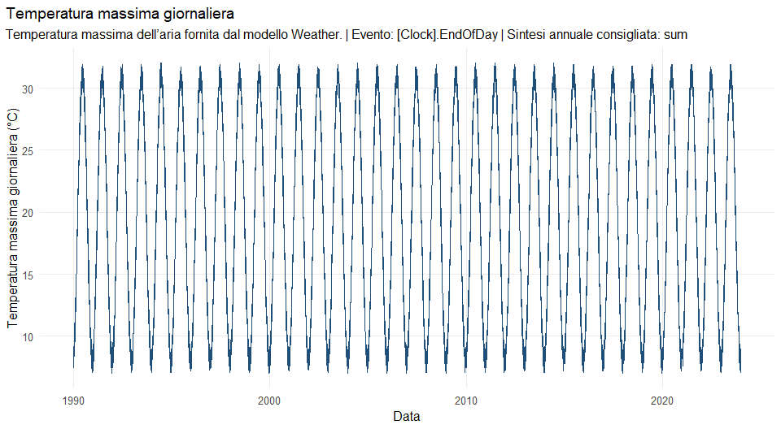

```r
numeric_daily <- names(daily)[vapply(daily, is.numeric, logical(1))]
daily_variable <- setdiff(
  numeric_daily,
  c("Year", "DOY", "SimulationID", "CheckpointID")
)[[1L]]
plot_spacing_daily(result, variable = daily_variable, x = "date")
```

# 7 Location

### 7.0.1 Checking simulation coordinates

`spacing_coordinates()` extracts the location represented by the result and attaches a readable label. `plot_spacing_location()` provides a static geographic check. Confirm that latitude and longitude match the intended site before interpreting agronomic outputs, especially when external weather or soil services are used.

The map validates location metadata; it does not validate the spatial representativeness of the soil profile or weather series.

```r
coordinates <- spacing_coordinates(result, label = "Maize reference run")
knitr::kable(coordinates)
```

| scenario_id | cell_id | latitude | longitude | rotation | mock | status | label |
| --- | --- | --- | --- | --- | --- | --- | --- |
| reference_maize_B_110_annual | CELL_449_106 | 44.9 | 10.63 | Maize | TRUE | 0 | Maize reference run |

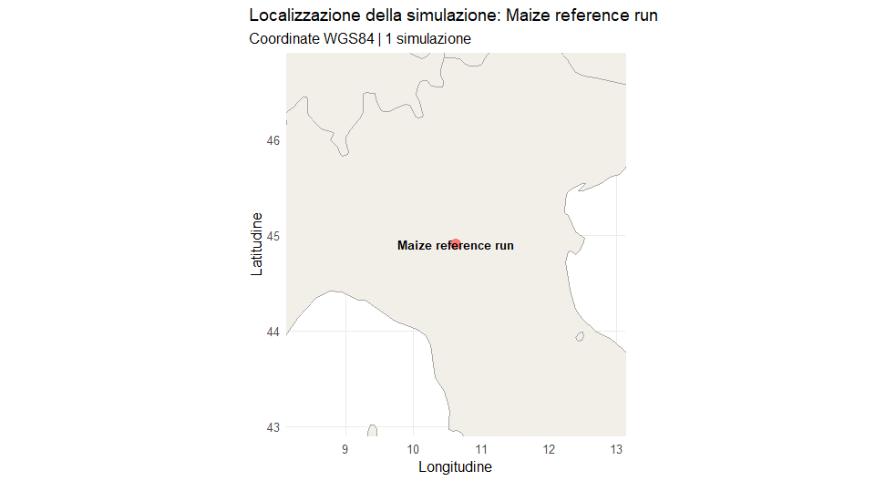

```r
plot_spacing_location(coordinates)
```

# 8 Soil profiles

### 8.0.1 Reading the soil-layer table

`spacing_soil_layers()` reconstructs the layer structure available in the result. Typical fields include upper and lower depth, thickness, water limits, bulk density, organic carbon, pH, nitrate, and ammonium, depending on the imported evidence.

Read layers from the surface downward. Always verify whether depths are in millimetres or centimetres and whether carbon is a concentration or an area-based stock. Layer thickness is essential when converting volumetric water or carbon concentrations into quantities per hectare.

```r
soil_layers <- spacing_soil_layers(result)
knitr::kable(soil_layers)
```

| layer | thickness_mm | depth_top_mm | depth_bottom_mm | depth_mid_mm | depth_label |
| --- | --- | --- | --- | --- | --- |
| 1 | 150 | 0 | 150 | 75 | 0-150 mm |
| 2 | 150 | 150 | 300 | 225 | 150-300 mm |
| 3 | 300 | 300 | 600 | 450 | 300-600 mm |
| 4 | 300 | 600 | 900 | 750 | 600-900 mm |
| 5 | 300 | 900 | 1200 | 1050 | 900-1200 mm |
| 6 | 600 | 1200 | 1800 | 1500 | 1200-1800 mm |

### 8.0.2 Selecting and interpreting layered variables

APSIMx often exports layer values using names ending in `(1)`, `(2)`, and so forth. The chunk detects these columns, derives the base variable names, and plots the first available variable as a time-depth surface.

The resulting colour field shows how the selected variable changes with date and depth. Confirm the selected variable before interpretation: the first detected variable is chosen only to demonstrate the API. Abrupt boundaries can reflect soil layers, while temporal bands can reflect management or weather events. The plot does not establish causation by itself.

```r
indexed <- grep("\\([0-9]+\\)$", names(daily), value = TRUE)
soil_variables <- unique(sub("\\([0-9]+\\)$", "", indexed))
soil_variables
```

```
#> [1] "SWmm"        "NO3_kgha"    "NH4_kgha"    "SoilC_kgCha"
#> [5] "CO2C_kgCha"  "N2O_kgNha"
```

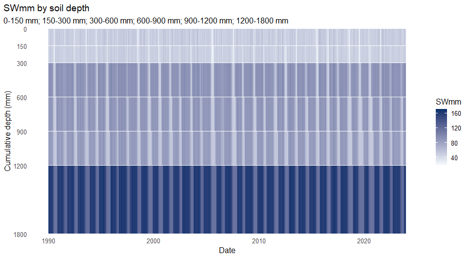

```r
if (length(soil_variables)) {
  print(plot_spacing_soil_profile(
    result,
    variable = soil_variables[[1L]],
    thickness = soil_layers$thickness_mm,
    type = "time_depth"
  ))
}
```

# 9 Irrigation actually applied

The plot is built directly from the APSIMx column containing applied irrigation. It does not represent the requested schedule when that column is unavailable.

### 9.0.1 Distinguishing irrigation requested from irrigation applied

The chunk searches the imported daily output for a numeric irrigation variable. When found, it constructs daily amounts and their cumulative sum. The figure therefore represents water exported by APSIMx as applied irrigation, not merely the irrigation rule sent in the request.

Read the daily line to identify event timing and magnitude, and the cumulative line to read total applied depth. Missing output means that the current report does not expose applied irrigation; it does not automatically mean that irrigation was disabled. Confirm the exact source column and unit before quoting totals.

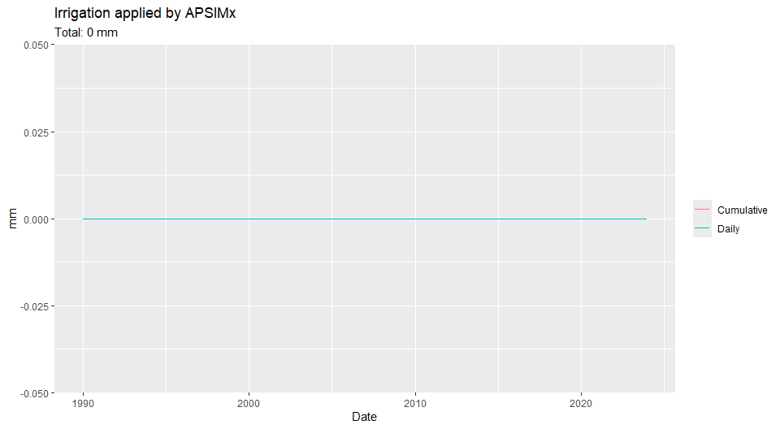

| date | irrigation_mm | cumulative_mm |
| --- | --- | --- |
| 1990-01-01 | 0 | 0 |
| 1990-02-01 | 0 | 0 |
| 1990-03-01 | 0 | 0 |
| 1990-04-01 | 0 | 0 |
| 1990-05-01 | 0 | 0 |
| 1990-06-01 | 0 | 0 |
| 1990-07-01 | 0 | 0 |
| 1990-08-01 | 0 | 0 |
| 1990-09-01 | 0 | 0 |
| 1990-10-01 | 0 | 0 |
| 1990-11-01 | 0 | 0 |
| 1990-12-01 | 0 | 0 |
| NA | 0 | 0 |
| NA | 0 | 0 |
| NA | 0 | 0 |
| NA | 0 | 0 |
| NA | 0 | 0 |
| NA | 0 | 0 |
| NA | 0 | 0 |
| NA | 0 | 0 |

```r
irrigation_column <- first_existing(
  daily,
  candidates = c("Irrig_mm", "Irrigation_mm", "Irrigation"),
  patterns = "irrig",
  numeric_only = TRUE
)

if (!is.na(irrigation_column)) {
  irrigation_data <- data.frame(
    date = result_dates(daily),
    irrigation_mm = as.numeric(daily[[irrigation_column]])
  )
  irrigation_data$irrigation_mm[is.na(irrigation_data$irrigation_mm)] <- 0
  irrigation_data$cumulative_mm <- cumsum(irrigation_data$irrigation_mm)

  irrigation_long <- rbind(
    data.frame(
      date = irrigation_data$date,
      series = "Daily",
      value = irrigation_data$irrigation_mm
    ),
    data.frame(
      date = irrigation_data$date,
      series = "Cumulative",
      value = irrigation_data$cumulative_mm
    )
  )

  irrigation_plot <- ggplot2::ggplot(
    irrigation_long,
    ggplot2::aes(x = date, y = value, colour = series)
  ) +
    ggplot2::geom_line() +
    ggplot2::labs(
      title = "Irrigation applied by APSIMx",
      subtitle = paste(
        "Total:", round(sum(irrigation_data$irrigation_mm), 2), "mm"
      ),
      x = "Date", y = "mm", colour = NULL
    )

  print(irrigation_plot)
  knitr::kable(preview(irrigation_data))
} else {
  cat("The run does not export a numeric column for applied irrigation.\n")
}
```

# 10 Fertilisation actually applied

### 10.0.1 Distinguishing the fertiliser plan from applied nitrogen

The chunk searches for a numeric APSIMx variable representing fertiliser N applied. Events are plotted as bars by date and summed in kg N/ha. The check is deliberately conservative: if no supported output column is found, the manual says that application cannot be verified from the imported evidence.

A requested schedule is an input. An exported event is evidence of what the simulation applied. Keep these concepts separate when validating management transfer. A zero value can be valid on non-application days; a missing column means unavailable evidence.

```r
fertilisation_column <- first_existing(
  daily,
  candidates = c(
    "FertiliserN_kgNha", "FertilizerN_kgNha",
    "NApplied_kgNha", "FertN_kgNha"
  ),
  patterns = c("fertili[sz].*n", "n.*applied", "fert.*kg"),
  numeric_only = TRUE
)

if (!is.na(fertilisation_column)) {
  fertilisation_data <- data.frame(
    date = result_dates(daily),
    nitrogen_kg_ha = as.numeric(daily[[fertilisation_column]])
  )
  fertilisation_data$nitrogen_kg_ha[is.na(fertilisation_data$nitrogen_kg_ha)] <- 0

  fertilisation_plot <- ggplot2::ggplot(
    fertilisation_data,
    ggplot2::aes(x = date, y = nitrogen_kg_ha)
  ) +
    ggplot2::geom_col(fill = "darkgreen", width = 1) +
    ggplot2::labs(
      title = "Fertiliser nitrogen exported by APSIMx",
      subtitle = paste(
        "Total:", round(sum(fertilisation_data$nitrogen_kg_ha), 2), "kg N/ha"
      ),
      x = "Date", y = "kg N/ha"
    )

  print(fertilisation_plot)
  knitr::kable(preview(fertilisation_data))
} else {
  cat(
    "The run does not export a column for applied fertiliser N; ",
    "the requested schedule is not presented as an event that was actually applied.\n",
    sep = ""
  )
}
```

```
#> The run does not export a column for applied fertiliser N; the requested schedule is not presented as an event that was actually applied.
```

# 11 Total soil carbon

### 11.0.1 Reading total soil carbon through time

The chunk identifies a total Soil C stock column, preserves the complete daily series, and subtracts the first value to show change from the fixture baseline. The zero line marks no change from the first simulated day.

The vertical axis is change in kg C/ha, not percentage change. Positive values indicate a larger stock than the first day; negative values indicate a smaller stock. Daily fluctuations and long-term trends should be interpreted in relation to the model’s carbon pools, residue inputs, decomposition, water, temperature, and nitrogen dynamics. This demonstration is not a calibrated estimate of sequestration for a real site.

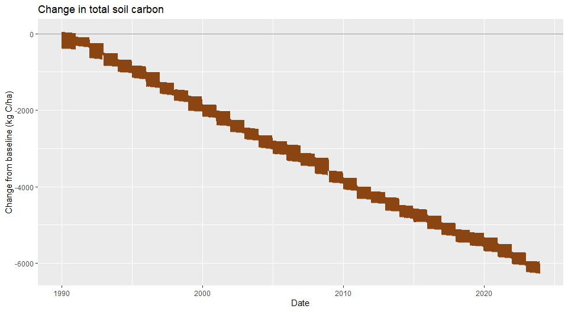

| date | stock_kgC_ha | change_kgC_ha |
| --- | --- | --- |
| 1990-01-01 | 148243.9 | 0.0000000 |
| 1990-02-01 | 148243.6 | -0.2896356 |
| 1990-03-01 | 148243.4 | -0.5570336 |
| 1990-04-01 | 148243.1 | -0.7985773 |
| 1990-05-01 | 148242.9 | -1.0528215 |
| 1990-06-01 | 148242.6 | -1.3114986 |
| 1990-07-01 | 148242.4 | -1.5473934 |
| 1990-08-01 | 148242.1 | -1.7873215 |
| 1990-09-01 | 148241.9 | -2.0165569 |
| 1990-10-01 | 148241.7 | -2.2532336 |
| 1990-11-01 | 148241.4 | -2.4747307 |
| 1990-12-01 | 148241.2 | -2.7029628 |
| NA | 148241.0 | -2.8904681 |
| NA | 148240.8 | -3.0874663 |
| NA | 148240.7 | -3.2460739 |
| NA | 148240.5 | -3.4687421 |
| NA | 148240.2 | -3.7063041 |
| NA | 148240.0 | -3.9399959 |
| NA | 148239.8 | -4.1622537 |
| NA | 148239.5 | -4.4126771 |

```r
soil_c_column <- first_existing(
  daily,
  candidates = c(
    "SoilCtot_kgCha", "SoilC_total_kgCha", "TotalSoilC_kgCha"
  ),
  patterns = c("soilc.*tot", "total.*soil.*c"),
  numeric_only = TRUE
)

if (!is.na(soil_c_column)) {
  soil_c_data <- data.frame(
    date = result_dates(daily),
    stock_kgC_ha = as.numeric(daily[[soil_c_column]])
  )
  soil_c_data$change_kgC_ha <-
    soil_c_data$stock_kgC_ha - soil_c_data$stock_kgC_ha[[1L]]

  soil_c_plot <- ggplot2::ggplot(
    soil_c_data,
    ggplot2::aes(x = date, y = change_kgC_ha)
  ) +
    ggplot2::geom_hline(yintercept = 0, colour = "grey60") +
    ggplot2::geom_line(colour = "saddlebrown", linewidth = 0.8) +
    ggplot2::labs(
      title = "Change in total soil carbon",
      x = "Date", y = "Change from baseline (kg C/ha)"
    )

  print(soil_c_plot)
  knitr::kable(preview(soil_c_data))
} else {
  cat("The run does not export a total soil carbon column.\n")
}
```

# 12 Carbon by soil layer

### 12.0.1 Reading carbon by soil layer

The code searches layered variables whose names contain Soil C or carbon while excluding CO2 fluxes. If a compatible variable exists, `plot_spacing_soil_profile(..., type = "profile")` displays its vertical distribution. Errors are trapped so that one unsupported variable does not prevent the entire manual from compiling.

A profile represents the selected variable across layers at the time or aggregation used by the plotting method. Compare profiles only when variable, unit, layer definition, and date are equivalent. The absence of a layered carbon output does not invalidate the total Soil C stock; it only limits vertical interpretation.

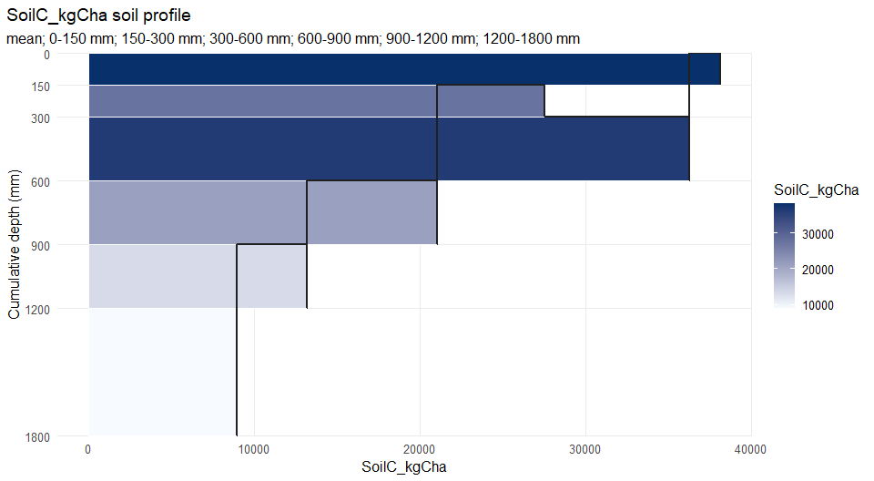

```r
soil_carbon_variables <- soil_variables[
  grepl("soilc|carbon", soil_variables, ignore.case = TRUE) &
    !grepl("co2", soil_variables, ignore.case = TRUE)
]

if (length(soil_carbon_variables)) {
  carbon_profile <- tryCatch(
    plot_spacing_soil_profile(
      result,
      variable = soil_carbon_variables[[1L]],
      thickness = soil_layers$thickness_mm,
      type = "profile"
    ),
    error = identity
  )

  if (inherits(carbon_profile, "ggplot")) {
    print(carbon_profile)
  } else {
    cat(
      "Carbon profile cannot be plotted: ",
      conditionMessage(carbon_profile), "\n",
      sep = ""
    )
  }
} else {
  cat("No layered soil carbon variable is available.\n")
}
```

# 13 Yield and grain

An empty `crop_summary` table is not sufficient to conclude that APSIMx produced no grain. The vignette checks all imported tables and displays columns associated with yield, grain, or harvest.

### 13.0.1 Why yield is searched across all imported tables

A crop-summary table can be empty even when another APSIMx report contains grain or harvest information. This chunk therefore flattens available CSV and DataStore tables and inventories every column whose name suggests yield, grain, or harvest. For numeric columns it records the number of positive values and the maximum.

This is an evidence-discovery step. A matching name does not guarantee that the column is harvested yield, and a maximum is not automatically the final crop yield. Use table name, column definition, unit, crop identity, and event date to select the authoritative response.

```r
all_tables <- c(
  flatten_tables(result$csv, "csv"),
  flatten_tables(result$datastore, "datastore")
)

yield_candidates <- do.call(rbind, lapply(names(all_tables), function(table_name) {
  data <- all_tables[[table_name]]
  columns <- grep(
    "yield|grain|harvest",
    names(data),
    value = TRUE,
    ignore.case = TRUE
  )
  if (!length(columns)) return(NULL)

  do.call(rbind, lapply(columns, function(column) {
    value <- data[[column]]
    data.frame(
      table = table_name,
      column = column,
      class = paste(class(value), collapse = "/"),
      positive_n = if (is.numeric(value)) sum(value > 0, na.rm = TRUE) else NA_integer_,
      maximum = if (is.numeric(value) && any(is.finite(value))) {
        max(value, na.rm = TRUE)
      } else {
        NA_real_
      },
      stringsAsFactors = FALSE
    )
  }))
}))

if (is.null(yield_candidates)) {
  yield_candidates <- data.frame(
    table = character(), column = character(), class = character(),
    positive_n = integer(), maximum = numeric()
  )
}
knitr::kable(yield_candidates)
```

| table | column | class | positive_n | maximum |
| --- | --- | --- | --- | --- |
| csv/crop_summary_CELL_449_106_CELL_449_106_S1_tool2_cli.csv | HarvestDate | logical | NA | NA |
| csv/crop_summary_CELL_449_106_CELL_449_106_S1_tool2_cli.csv | Yield_kgha | logical | NA | NA |
| csv/daily_CELL_449_106_CELL_449_106_S1_tool2_cli.csv | Maize_GrainWt_kgha | numeric | 2270 | 11450.66 |
| csv/report_CELL_449_106_CELL_449_106_S1_tool2_cli.csv | Maize_GrainYield_kgha | numeric | 34 | 11450.66 |
| datastore/spacing_CELL_449_106__CELL_449_106_S1__tool2_cli.db/DailyReport | Maize_GrainWt_kgha | numeric | 2270 | 11450.66 |
| datastore/spacing_CELL_449_106__CELL_449_106_S1__tool2_cli.db/Report | Maize_GrainYield_kgha | numeric | 34 | 11450.66 |

### 13.0.2 Reading the yield-candidate plot

The bars display the maximum positive value for each candidate column, grouped by originating table. The chart makes duplicate representations and scale differences visible, but it intentionally avoids labelling every candidate as yield.

Do not sum bars, compare variables with different units, or treat duplicated tables as independent outcomes. The correct next step is to select the crop-specific harvest or yield variable documented by the APSIMx report configuration.

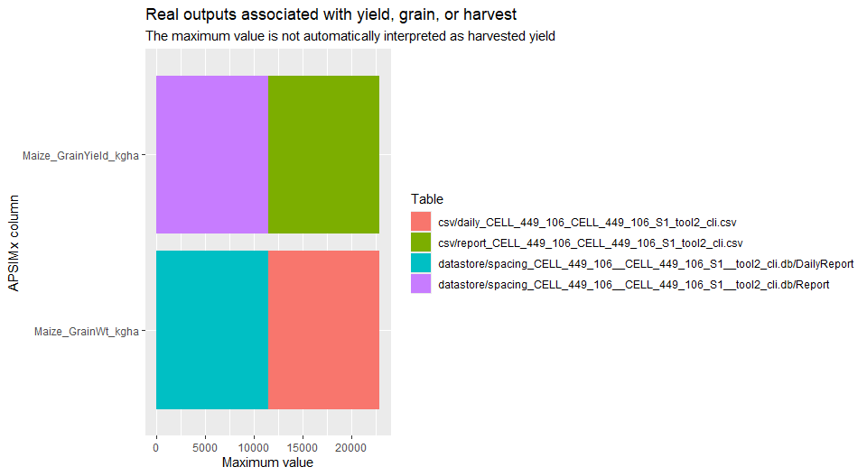

```r
usable_yield <- yield_candidates[
  is.finite(yield_candidates$maximum) & yield_candidates$maximum > 0,
  , drop = FALSE
]

if (nrow(usable_yield)) {
  yield_plot <- ggplot2::ggplot(
    usable_yield,
    ggplot2::aes(
      x = reorder(column, maximum),
      y = maximum,
      fill = table
    )
  ) +
    ggplot2::geom_col() +
    ggplot2::coord_flip() +
    ggplot2::labs(
      title = "Real outputs associated with yield, grain, or harvest",
      subtitle = paste(
        "The maximum value is not automatically interpreted as harvested yield"
      ),
      x = "APSIMx column", y = "Maximum value", fill = "Table"
    )
  print(yield_plot)
} else {
  cat("No positive value associated with yield, grain, or harvest.\n")
}
```

# 14 Limited plot atlas

The atlas is built with package functions. Each plot is validated individually; an invalid plot is reported without stopping the vignette.

### 14.0.1 Using the plot atlas for exploration

`plot_spacing_atlas()` attempts a limited set of daily, report, and soil plots and returns a named list. Each candidate is built separately; failures are captured in the `errors` attribute and do not stop the vignette. This is useful when first exploring an unfamiliar result object.

The atlas is a discovery aid, not an automatic scientific report. Select a small set of variables with known definitions and units for final communication. An atlas error usually means that a variable is empty, incompatible with the requested geometry, or unavailable in the fixture.

```r
atlas <- plot_spacing_atlas(
  result,
  sources = c("daily", "report", "soil"),
  daily_x = "date",
  soil_types = c("time_depth", "profile"),
  max_plots = 4
)

names(atlas)
```

```
#>  [1] "daily/Tx"                     "daily/Tn"
#>  [3] "daily/Rain_mm"                "daily/Radn_MJm2"
#>  [5] "report/Maize_GrainYield_kgha" "report/Maize_Biomass_kgha"
#>  [7] "report/Maize_LAI"             "report/SoilNO3_kgha"
#>  [9] "soil/SWmm/time_depth"         "soil/SWmm/profile"
#> [11] "soil/NO3_kgha/time_depth"     "soil/NO3_kgha/profile"
#> [13] "soil/NH4_kgha/time_depth"     "soil/NH4_kgha/profile"
#> [15] "soil/SoilC_kgCha/time_depth"  "soil/SoilC_kgCha/profile"
```

```r
attr(atlas, "errors")
```

```
#> list()
```

```
#>
#>
#> ### daily/Tx
```

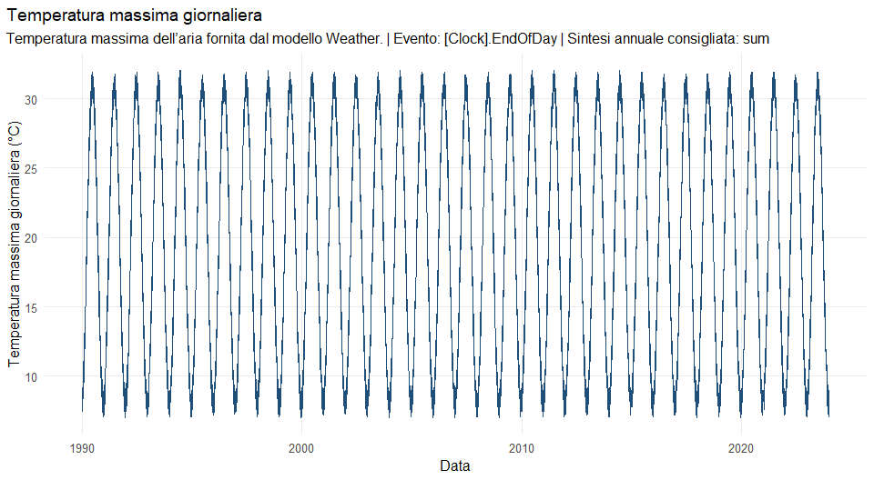

```
#>
#>
#> ### daily/Tn
```

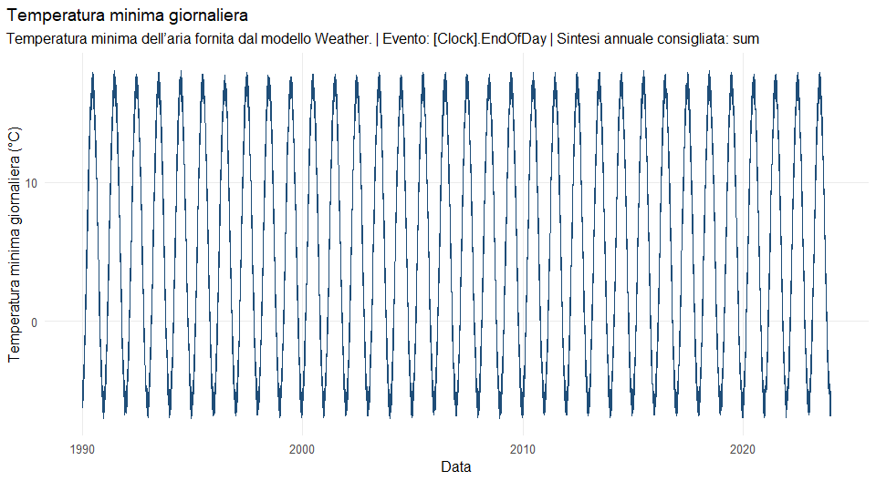

```
#>
#>
#> ### daily/Rain_mm
```

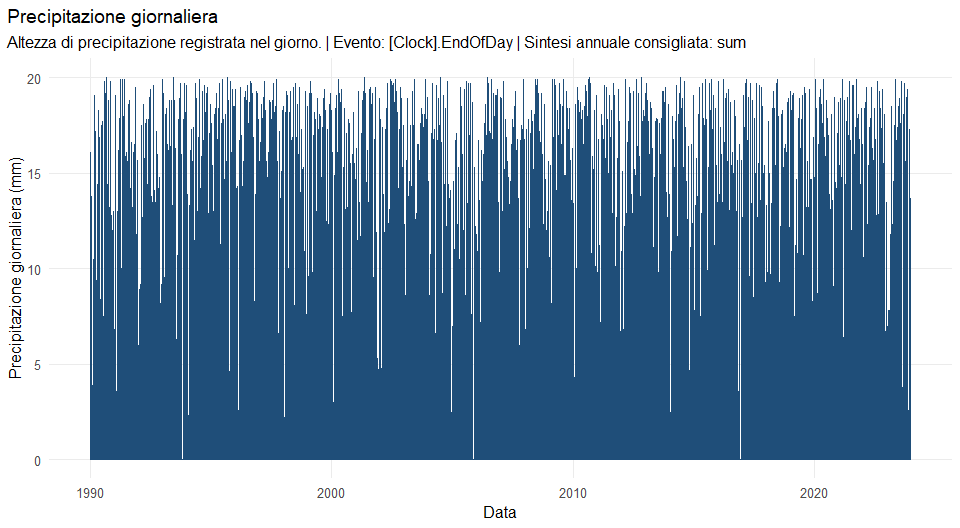

```
#>
#>
#> ### daily/Radn_MJm2
```

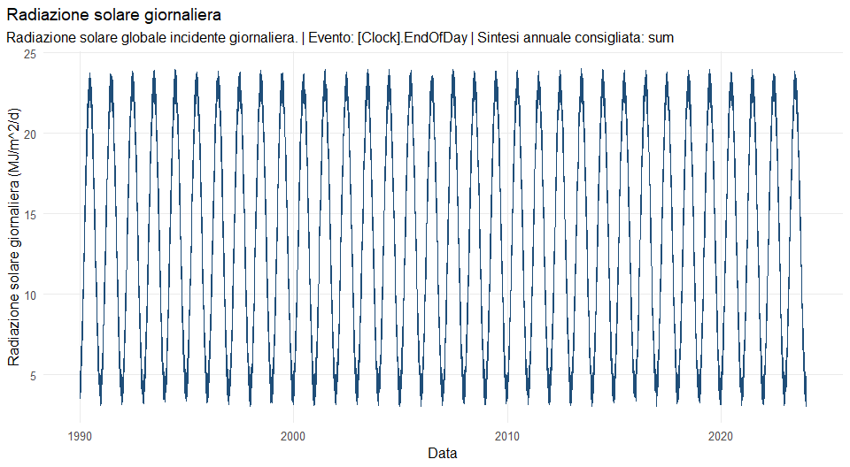

```
#>
#>
#> ### report/Maize_GrainYield_kgha
```

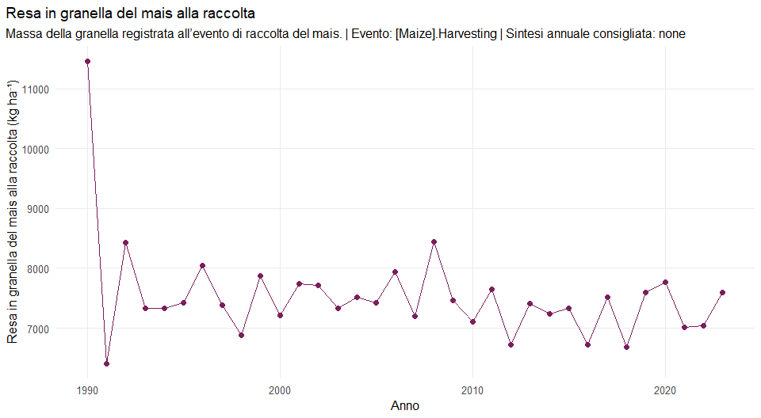

```
#>
#>
#> ### report/Maize_Biomass_kgha
```

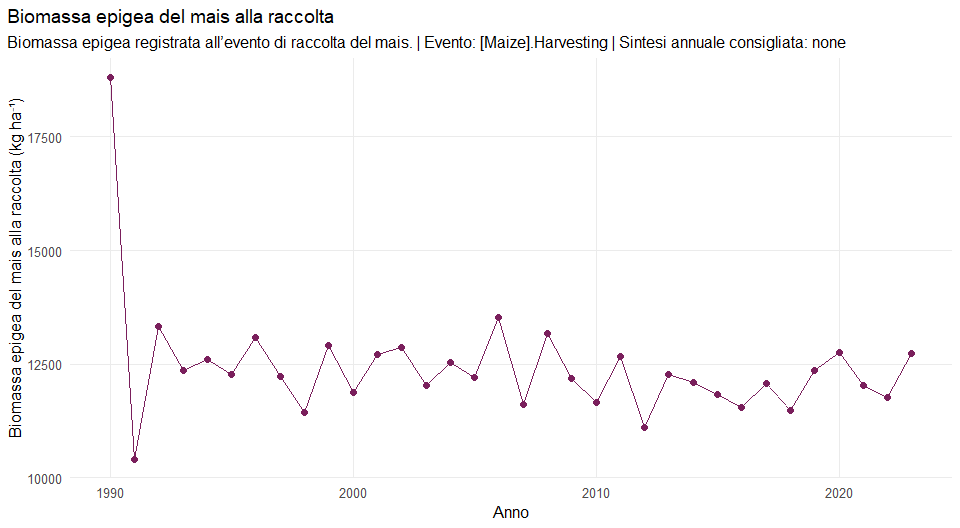

```
#>
#>
#> ### report/Maize_LAI
```

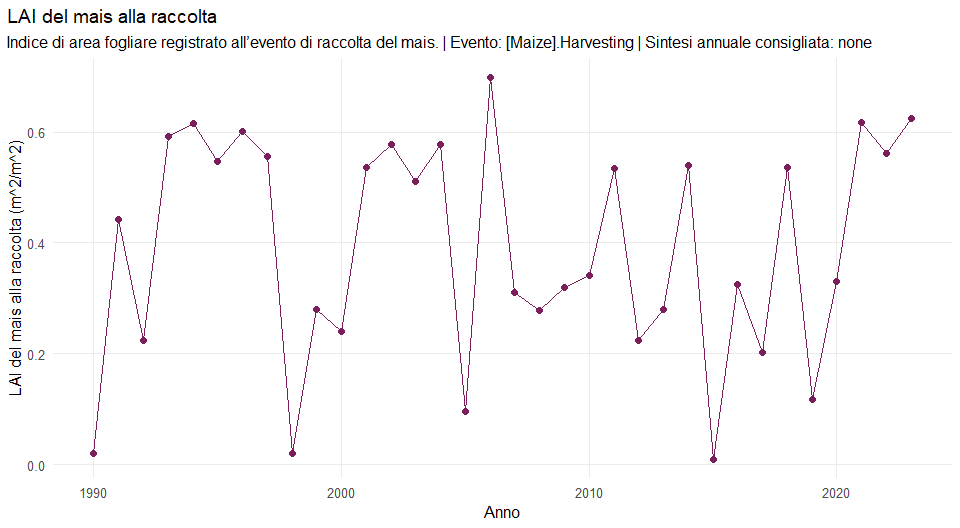

```
#>
#>
#> ### report/SoilNO3_kgha
```

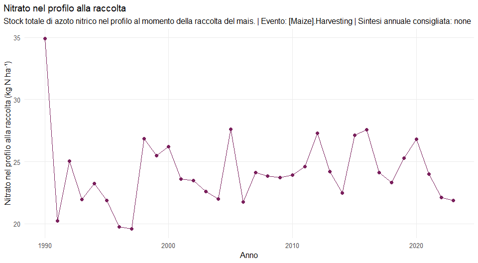

```r
for (plot_name in utils::head(names(atlas), 8L)) {
  candidate <- tryCatch(
    {
      ggplot2::ggplot_build(atlas[[plot_name]])
      atlas[[plot_name]]
    },
    error = identity
  )

  cat("\n\n### ", plot_name, "\n\n", sep = "")
  if (inherits(candidate, "ggplot")) {
    print(candidate)
  } else {
    cat(
      "Plot cannot be rendered: ",
      conditionMessage(candidate), "\n",
      sep = ""
    )
  }
}
```

# 15 Run spec and parameters

### 15.0.1 Defining a multi-year rotation declaratively

A rotation specification records ordered crop phases, cultivars, years, and whether the sequence repeats. The example describes the Wheat-Maize-Soybean-Wheat-Maize sequence used in the five-year workflow. A specification is an R-side description that can be validated, stored, compared, and later translated into a model request.

Inspect phase order and cultivar names carefully. A valid R object does not guarantee that every cultivar exists in the target APSIMx model; that compatibility is checked when the request is built or executed.

```r
rotation <- new_spacing_rotation_spec(
  name = "Wheat-Maize-Soybean-2020-2024",
  phases = list(
    list(Year = 2020, Crop = "Wheat", Cultivar = "Hartog"),
    list(Year = 2021, Crop = "Maize", Cultivar = "B_110"),
    list(Year = 2022, Crop = "Soybean", Cultivar = "Generic_MG1"),
    list(Year = 2023, Crop = "Wheat", Cultivar = "Hartog"),
    list(Year = 2024, Crop = "Maize", Cultivar = "B_110")
  ),
  repeat_rotation = FALSE
)
print(rotation)
```

```
#> $Name
#> [1] "Wheat-Maize-Soybean-2020-2024"
#>
#> $Repeat
#> [1] FALSE
#>
#> $Phases
#> $Phases[[1]]
#> $Phases[[1]]$SowingWindow
#> NULL
#>
#> $Phases[[1]]$Population
#> NULL
#>
#> $Phases[[1]]$Depth
#> NULL
#>
#> $Phases[[1]]$RowSpacing
#> NULL
#>
#> $Phases[[1]]$HarvestRule
#> [1] "IsReadyForHarvesting"
#>
#> $Phases[[1]]$ResidueFractionRetained
#> [1] 1
#>
#> $Phases[[1]]$Year
#> [1] 2020
#>
#> $Phases[[1]]$Crop
#> [1] "Wheat"
#>
#> $Phases[[1]]$Cultivar
#> [1] "Hartog"
#>
#>
#> $Phases[[2]]
#> $Phases[[2]]$SowingWindow
#> NULL
#>
```

[output cut: 103 more lines]

```
#> [1] 2024
#>
#> $Phases[[5]]$Crop
#> [1] "Maize"
#>
#> $Phases[[5]]$Cultivar
#> [1] "B_110"
#>
#>
#>
#> $Metadata
#> list()
#>
#> attr(,"class")
#> [1] "spacing_rotation_spec" "list"
```

### 15.0.2 Defining parameters for sensitivity or calibration

The catalogue associates a readable parameter ID with crop, scope, exact APSIMx path, type, unit, admissible bounds, transformation, and application stage. `validate_spacing_parameters()` checks proposed values against this contract before a model run.

Bounds define the analysis domain, not biological confidence intervals. The APSIMx path must be confirmed against the model and cultivar actually used. For large Morris or calibration experiments, perform an isolated preflight for every parameter before constructing the full design.

```r
catalogue <- spacing_parameter_catalogue(
  parameter_id = "maize_rue",
  crop = "Maize",
  scope = "cultivar",
  apsim_path = "Leaf.Photosynthesis.RUE.FixedValue",
  type = "double",
  unit = "g/MJ",
  lower_bound = 1.2,
  upper_bound = 3.2,
  transform = "identity",
  application_stage = "cultivar"
)
knitr::kable(catalogue)
```

| parameter_id | crop | scope | apsim_path | type | unit | lower_bound | upper_bound | transform | application_stage |
| --- | --- | --- | --- | --- | --- | --- | --- | --- | --- |
| maize_rue | Maize | cultivar | Leaf.Photosynthesis.RUE.FixedValue | double | g/MJ | 1.2 | 3.2 | identity | cultivar |

```r
validate_spacing_parameters(list(maize_rue = 2.0), catalogue)
```

```
#> $maize_rue
#> [1] 2
```

# 16 Recommended workflow for a new user

1. Install `rSpacing` with the vignette and open this manual.
2. Inspect the supplied fixture with `inventory_spacing_result()` and the dedicated table accessors.
3. Identify variables by exact name and unit before plotting or aggregating them.
4. Configure the external `Spacing.Tool2` runtime and verify `.NET` with a small `mock = TRUE` request.
5. Inspect status, standard output, standard error, generated files, and the imported `spacing_result`.
6. Reproduce the single Maize example before creating a multi-year rotation.
7. Validate soil, management, request, and parameter objects before launching simulations.
8. Use preflight runs before Morris, uncertainty, calibration, or large batches.
9. Keep run folders separate from persistent results and record package, C# runtime, request, and commit versions.

# 17 Troubleshooting checklist

- **The vignette is not listed after installation.** Install with `build_vignettes = TRUE` or install a source tarball built with vignettes.
- **The fixture cannot be found.** Confirm that `inst/extdata/reference_maize/result.rds` is present in the source package and `extdata/reference_maize/result.rds` is present after installation.
- **`dotnet` is not found.** Run `Sys.which("dotnet")` and `system2("dotnet", "--info")`; install or configure .NET 8 before model execution.
- **The C# runtime is not found.** Set `RSPACING_SPACING_ROOT` to the local `apsim` repository containing `src/Spacing.Tool2`.
- **The model run fails.** Inspect the run status, `stdout`, `stderr`, request JSON, configuration JSON, and manifest before changing R code.
- **A table is empty.** Check the complete result inventory and DataStore tables. An empty crop summary does not prove that no crop output exists.
- **A plot is empty or fails.** Verify variable name, numeric type, non-missing values, unit, and temporal or layered structure.
- **Management cannot be verified.** Distinguish the requested management object from APSIMx output evidence of applied events.
- **Yield or biomass values are duplicated across crops.** Require exact crop-specific columns rather than selecting the first name matching a general pattern.

# 18 Scope and limitations

The bundled fixture is a reproducible demonstration of the `rSpacing` interface. It uses mock weather and a predefined model configuration. The manual teaches how to inspect evidence and construct reproducible workflows; it does not establish that the simulated agronomic or environmental values are calibrated for a particular site. Scientific interpretation requires appropriate observed data, defensible input distributions, validated management transfer, model-version control, and explicit documentation of units and aggregation rules.